# VOCs Vendy

Anna Mrazova

2025-03-13

# VOC analyses

## Used libraries

```r
library(Matrix)
library(lme4)
library(dplyr)
library(tidyverse)
library(car)
library(glmmTMB)
library(emmeans)
library(MuMIn)
library(DHARMa)
library(vegan)
library(ggplot2)
library(FactoMineR)
library(factoextra)
library(dplyr)
library(tidyr)
library(tibble)
```

## 1 STROMY BEZ MeJA

## A) mnozství VOC ~ druh

### Data filtering

```r
setwd("C:/Users/annam/OneDrive - Biologické centrum AV ČR, v. v. i/Anawork/Students/Vendula Bilkova/Data/voc")
data1A <- read.csv2("RStudio data 1.csv", dec = ",", header = TRUE, stringsAsFactors = FALSE)
data1A <- subset(data1A, grepl("kontr_pid|kontr_ostruh", Treatment, ignore.case = TRUE))
data1A <- subset(data1A, Compound == "Total_Standard")
data1A$Treatment <- as.factor(data1A$Treatment)
data1A$Value <- as.numeric(data1A$Value)
```

### Perform appropriate test

#### Based on data diagnosis tests:

#### **1)** check for normality and equal variaces hold, we we go for a simple t-test

#### **2)** If normality is violated, go for non-parametric wilcoxon test

```r
# Check normality assumption per group
shapiro_test_ostr <- shapiro.test(data1A$Value[data1A$Treatment == "kontr_ostruh"])
shapiro_test_pid <- shapiro.test(data1A$Value[data1A$Treatment == "kontr_pid"])

if (shapiro_test_ostr$p.value > 0.05 & shapiro_test_pid$p.value > 0.05) {
  if (levene_test$`Pr(>F)`[1] > 0.05) {
       test_result <- t.test(Value ~ Treatment, data = data1A, var.equal = TRUE)
  }
} else {
    test_result <- wilcox.test(Value ~ Treatment, data = data1A)
}
print(test_result)
```

```
##
##  Wilcoxon rank sum exact test
##
## data:  Value by Treatment
## W = 46, p-value = 0.1605
## alternative hypothesis: true location shift is not equal to 0
```

### Visualisation

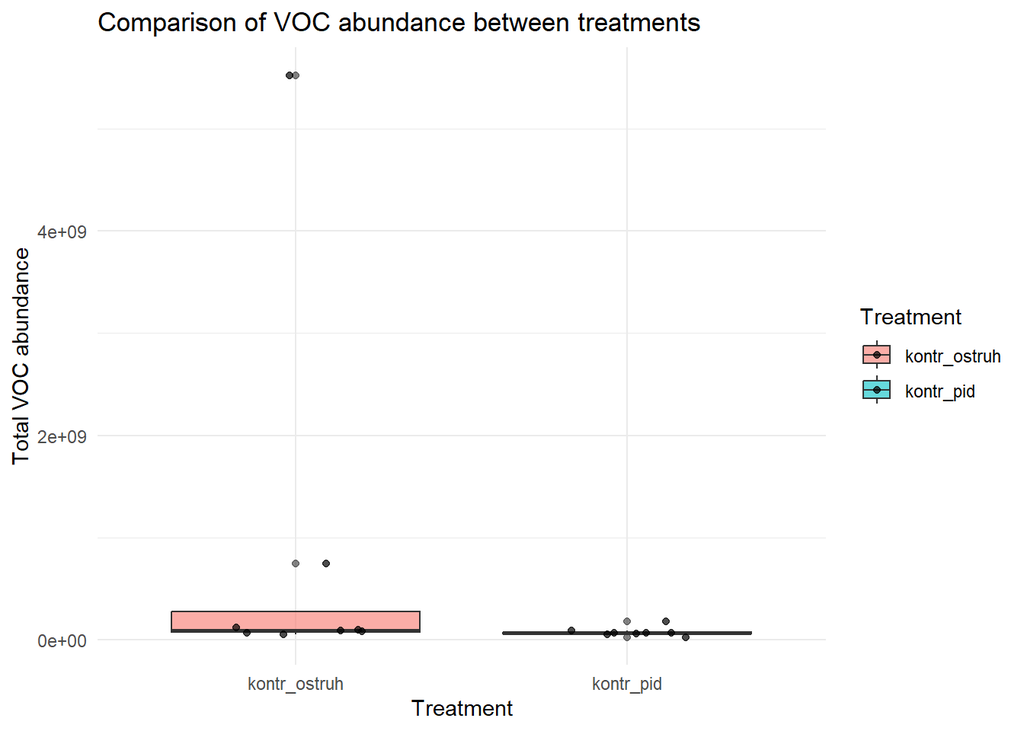

```r
ggplot(data1A, aes(x = Treatment, y = Value, fill = Treatment)) +
  geom_boxplot(alpha = 0.6) +
  geom_jitter(width = 0.2, alpha = 0.7) +
  theme_minimal() +
  labs(title = "Comparison of VOC abundance between treatments",
       y = "Total VOC abundance",
       x = "Treatment")
```

### Results t-test

#### wilcoxon test for non normally distributed data - **treatment has no effect**.

## B) an overall VOC variation between treatments - PCA

### Data manipulation

```r
data1B <- read.csv2("RStudio data 1.csv", dec = ",", header = TRUE, stringsAsFactors = FALSE)
data1B <- subset(data1B, grepl("kontr_pid|kontr_ostruh", Treatment, ignore.case = TRUE))
data1B <- data1B %>% filter(Compound != "Total_Standard")

# log transformation for values
data1B$log_Value <- log(data1B$Value)

# Prepare VOC data in wide format
VOC_matrix <- data1B %>%
  select(ID, Compound, log_Value) %>%
  pivot_wider(names_from = Compound, values_from = log_Value) %>%
  left_join(data1B %>% select(ID, Treatment) %>% distinct(), by = "ID") %>%
  column_to_rownames(var = "ID")

# Convert Treatment to a factor
VOC_matrix$Treatment <- as.factor(VOC_matrix$Treatment)
```

### PCA 1

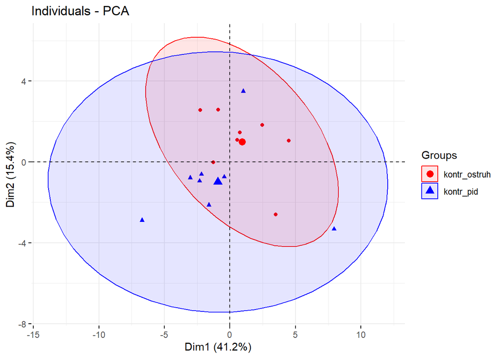

```r
# Run PCA excluding the Treatment column
pca_result <- PCA(VOC_matrix %>% select(-Treatment), scale.unit = TRUE, graph = FALSE)

# Visualize PCA with treatment groups
palette_colors <- c("red", "blue")
fviz_pca_ind(pca_result,
             label = "none",
             habillage = VOC_matrix$Treatment,
             addEllipses = TRUE,
             ellipse.level = 0.95,
             palette = palette_colors)
```

### Results PCA

#### **Ellipses Indicate Group Variability:**

#### The blue ellipse (kontr_pid) is larger, suggesting higher within-group variance. The red ellipse (kontr_ostruh) is more compact, meaning these samples have more similar VOC profiles.

## C) Effect of treatment (species feeding) on individual compounds

### Fitting model and variable selection

```r
model1C <- glmer(Value ~ Treatment * Compound + (1|ID), data = data1B, family = Gamma(link = "log"))

model1C <- glmmTMB(Value ~ Treatment * Compound + (1|ID), data = data1B, family = Gamma(link = "log"))

reduced1 <- update(model1C, . ~ . - Compound)
reduced2 <- update(model1C, . ~ . - Treatment)
reduced3 <- update(model1C, . ~ . - Compound:Treatment)
Null <- glmmTMB(Value ~ 1 + (1|ID), data = data1B, family = Gamma(link = "log"))

# Compare models using AICc
models_list <- list(model1C, reduced1, reduced2, reduced3, Null)
model_selection <- model.sel(models_list, rank = AICc)
print(model_selection)
```

```
## Model selection table
##   cnd((Int)) dsp((Int)) cnd(Cmp) cnd(Trt) cnd(Cmp:Trt) df    logLik    AICc
## 2      15.47          +                 +            + 56 -6376.565 12882.2
## 3      15.47          +        +                     + 56 -6376.565 12882.2
## 1      15.47          +        +        +            + 56 -6376.565 12882.2
## 4      15.95          +        +        +              30 -6419.629 12903.9
## 5      15.29          +                                 3 -6843.049 13692.2
##    delta weight
## 2   0.00  0.333
## 3   0.00  0.333
## 1   0.00  0.333
## 4  21.74  0.000
## 5 810.00  0.000
## Models ranked by AICc(x)
## Random terms (all models):
##   cond(1 | ID)
```

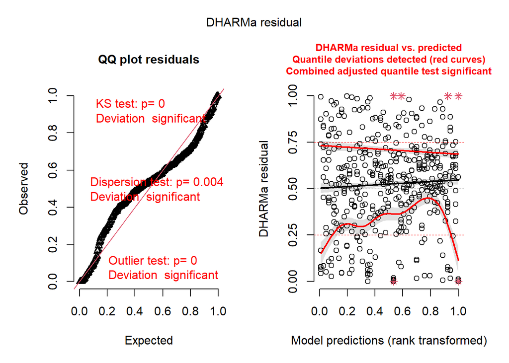

```r
# Diagnosis check
simulationOutput <- simulateResiduals(fittedModel = model1C, n = 1000)
plot(simulationOutput)
```

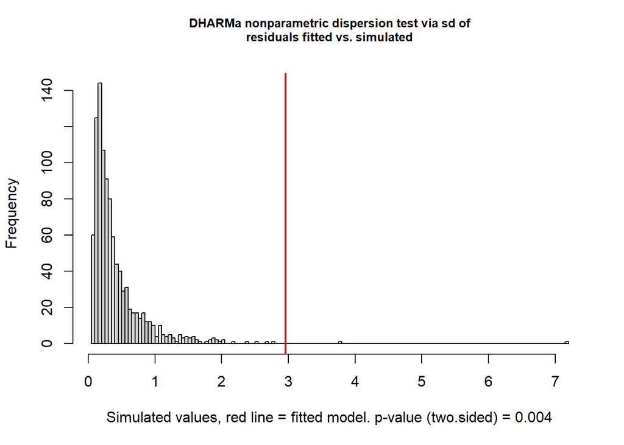

```
##
##  DHARMa nonparametric dispersion test via sd of residuals fitted vs.
##  simulated
##
## data:  simulationOutput
## dispersion = 7.0811, p-value = 0.004
## alternative hypothesis: two.sided
```

```r
testDispersion(simulationOutput)
```

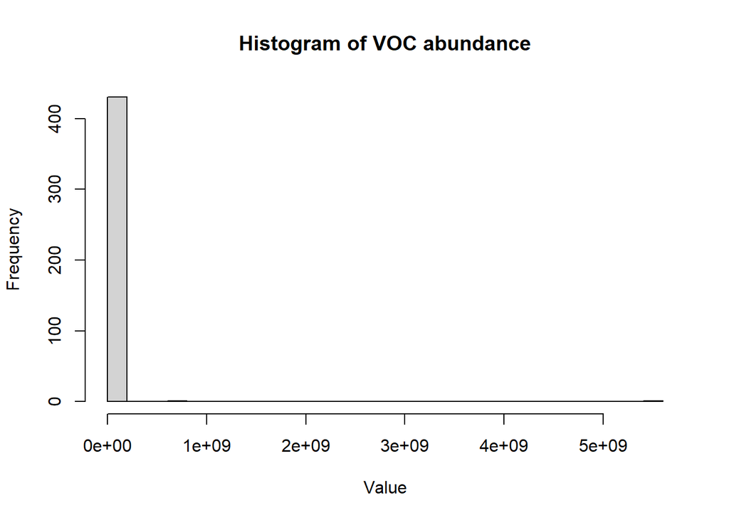

```r
hist(data1B$Value, breaks = 30, main = "Histogram of VOC abundance", xlab = "Value")
```

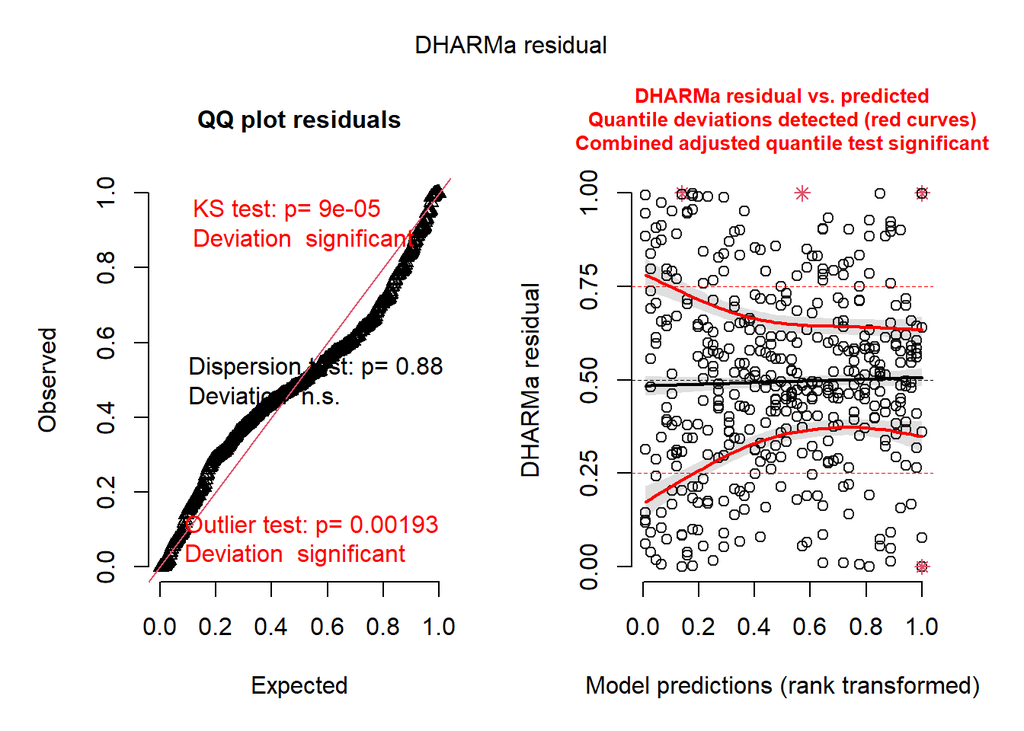

```r
# -> log transformarion
data1B$log_Value <- log(data1B$Value)

model_logT <- glmmTMB(log_Value ~ Treatment * Compound + (1|ID),
                      data = data1B, family = gaussian)
simulationOutput_logT <- simulateResiduals(fittedModel = model_logT, n = 1000)
plot(simulationOutput_logT)
```

```r
summary(model_logT)
```

```
##  Family: gaussian  ( identity )
## Formula:          log_Value ~ Treatment * Compound + (1 | ID)
## Data: data1B
##
##      AIC      BIC   logLik deviance df.resid
##   1180.1   1407.9   -534.0   1068.1      376
##
## Random effects:
##
## Conditional model:
##  Groups   Name        Variance Std.Dev.
##  ID       (Intercept) 0.07828  0.2798
##  Residual             0.65789  0.8111
## Number of obs: 432, groups:  ID, 16
##
## Dispersion estimate for gaussian family (sigma^2): 0.658
##
## Conditional model:
##                                                       Estimate Std. Error
## (Intercept)                                           15.25914    0.30335
## Treatmentkontr_pid                                     0.20284    0.42900
## Compound2-Decen-1-ol_Standard                          0.35791    0.40555
## CompoundAcetic_acid_Standard                          -0.05056    0.40555
## CompoundButan-1-ol_Standard                            0.03970    0.40555
## CompoundMethyl_salicilate_Standard                     1.79968    0.40555
## CompoundUnknown_1_Standard                            -4.20916    0.40555
## CompoundUnknown_10_Standard                            1.17993    0.40555
## CompoundUnknown_11_Standard                           -3.53605    0.40555
## CompoundUnknown_12_Standard                            0.17921    0.40555
## CompoundUnknown_13_Standard                           -1.63071    0.40555
## CompoundUnknown_14_Standard                           -2.39075    0.40555
## CompoundUnknown_15_Standard                           -1.64455    0.40555
## CompoundUnknown_16_Standard                           -0.13760    0.40555
## CompoundUnknown_17_Standard                           -0.83044    0.40555
## CompoundUnknown_18_Standard                           -2.76726    0.40555
## CompoundUnknown_19_Standard                           -3.13722    0.40555
## CompoundUnknown_2_Standard                            -2.63111    0.40555
## CompoundUnknown_20_Standard                           -1.77073    0.40555
## CompoundUnknown_21_Standard                           -2.85476    0.40555
## CompoundUnknown_22_Standard                           -1.24968    0.40555
```

[output cut: 75 more lines]

```
## Treatmentkontr_pid:CompoundUnknown_18_Standard          -1.27  0.20348
## Treatmentkontr_pid:CompoundUnknown_19_Standard          -1.96  0.04969 *
## Treatmentkontr_pid:CompoundUnknown_2_Standard           -0.90  0.37061
## Treatmentkontr_pid:CompoundUnknown_20_Standard          -0.40  0.68731
## Treatmentkontr_pid:CompoundUnknown_21_Standard          -0.34  0.73252
## Treatmentkontr_pid:CompoundUnknown_22_Standard          -1.63  0.10375
## Treatmentkontr_pid:CompoundUnknown_3_Standard           -0.96  0.33577
## Treatmentkontr_pid:CompoundUnknown_4_Standard           -0.93  0.35329
## Treatmentkontr_pid:CompoundUnknown_5_Standard           -0.92  0.35805
## Treatmentkontr_pid:CompoundUnknown_6_Standard           -1.08  0.27952
## Treatmentkontr_pid:CompoundUnknown_7_Standard           -0.70  0.48415
## Treatmentkontr_pid:CompoundUnknown_8_Standard           -1.52  0.12865
## Treatmentkontr_pid:CompoundUnknown_9_Standard           -0.41  0.68265
## ---
## Signif. codes:  0 '***' 0.001 '**' 0.01 '*' 0.05 '.' 0.1 ' ' 1
```

```r
emmeans(model_logT, pairwise ~ Treatment, by = "Compound", type = "response")
```

```
## $emmeans
## Compound = (Z)-3-Hexen-1-ol_acetate_Standard:
##  Treatment    emmean    SE  df lower.CL upper.CL
##  kontr_ostruh  15.26 0.303 376    14.66    15.86
##  kontr_pid     15.46 0.303 376    14.87    16.06
##
## Compound = 2-Decen-1-ol_Standard:
##  Treatment    emmean    SE  df lower.CL upper.CL
##  kontr_ostruh  15.62 0.303 376    15.02    16.21
##  kontr_pid     15.55 0.303 376    14.95    16.14
##
## Compound = Acetic_acid_Standard:
##  Treatment    emmean    SE  df lower.CL upper.CL
##  kontr_ostruh  15.21 0.303 376    14.61    15.81
##  kontr_pid     14.99 0.303 376    14.39    15.59
##
## Compound = Butan-1-ol_Standard:
##  Treatment    emmean    SE  df lower.CL upper.CL
##  kontr_ostruh  15.30 0.303 376    14.70    15.90
##  kontr_pid     14.74 0.303 376    14.14    15.33
##
## Compound = Methyl_salicilate_Standard:
##  Treatment    emmean    SE  df lower.CL upper.CL
##  kontr_ostruh  17.06 0.303 376    16.46    17.66
##  kontr_pid     15.57 0.303 376    14.97    16.16
##
## Compound = Unknown_1_Standard:
##  Treatment    emmean    SE  df lower.CL upper.CL
##  kontr_ostruh  11.05 0.303 376    10.45    11.65
##  kontr_pid     10.43 0.303 376     9.83    11.02
##
## Compound = Unknown_10_Standard:
##  Treatment    emmean    SE  df lower.CL upper.CL
##  kontr_ostruh  16.44 0.303 376    15.84    17.04
##  kontr_pid     16.43 0.303 376    15.84    17.03
##
## Compound = Unknown_11_Standard:
##  Treatment    emmean    SE  df lower.CL upper.CL
##  kontr_ostruh  11.72 0.303 376    11.13    12.32
##  kontr_pid     12.05 0.303 376    11.45    12.64
```

[output cut: 191 more lines]

```
## Compound = Unknown_6_Standard:
##  contrast                 estimate    SE  df t.ratio p.value
##  kontr_ostruh - kontr_pid  0.41738 0.429 376   0.973  0.3312
##
## Compound = Unknown_7_Standard:
##  contrast                 estimate    SE  df t.ratio p.value
##  kontr_ostruh - kontr_pid  0.19843 0.429 376   0.463  0.6440
##
## Compound = Unknown_8_Standard:
##  contrast                 estimate    SE  df t.ratio p.value
##  kontr_ostruh - kontr_pid  0.66863 0.429 376   1.559  0.1199
##
## Compound = Unknown_9_Standard:
##  contrast                 estimate    SE  df t.ratio p.value
##  kontr_ostruh - kontr_pid  0.03166 0.429 376   0.074  0.9412
```